# Bericht 1 Fallstudien

2025-10-17

Die erhobenen Daten sind Erhebungen zu dem Thema Glücksempfinden in insgesamt 165 Ländern die über die Jahre 2005 bis 2018 erhoben wurden. Es gibt 24 Variablen die für ein Land in einem Jahr jeweils erhoben wurden. In dem vorliegenden Datensatz liegen insgesamt 1784 Beobachtungen vor.

Um zu ermitteln welche Länder den höchsten Zufriedenheitswert haben wird der jeweilige Durchschnitt über die in den Daten vorhandenen Jahre beobachtete Zufriedenheit berechnet. Anschließend werden die Länder nach diesem Durchschnittswert sortiert. Woraus sich eine Liste ergibt welche Länder sich gut und nicht gut zum auswandern eignen.

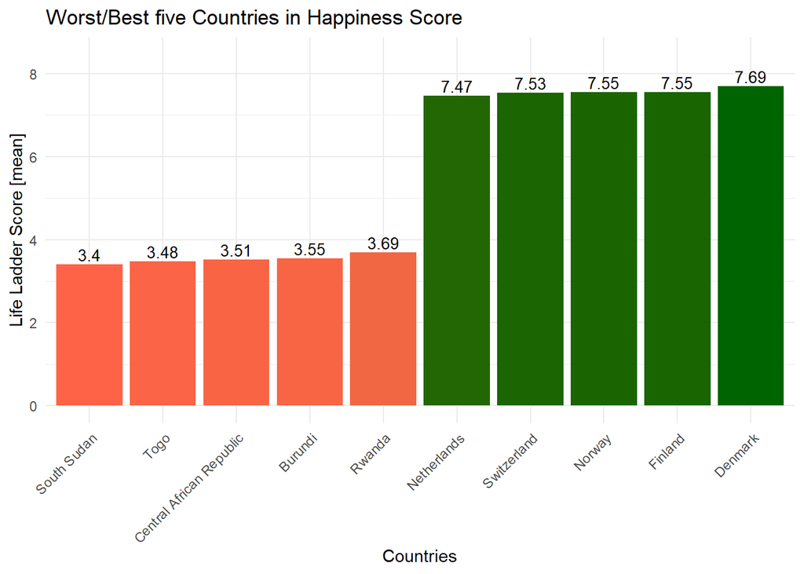

```r
# Grafiken im Mittel
ggplot(best_worst, aes(x = reorder(Country_name, Life_Ladder),
                       y = Life_Ladder,
                       fill = Life_Ladder)) +
  geom_bar(stat = "identity") +
  scale_fill_gradient(low = "tomato", high = "darkgreen", guide = "none") +
  geom_text(aes(label = round(Life_Ladder, 2)),
            vjust = -0.3, size = 3.5) +
  labs(x = "Countries",
       y = "Life Ladder Score [mean]",
       title = "Worst/Best five Countries in Happiness Score") +
  theme_minimal() +
  theme(axis.text.x = element_text(angle = 45, hjust = 1)) +
  coord_cartesian(ylim = c(0,max(best_worst$Life_Ladder)*1.1))
```

In der Abbildung sind die fünf Länder mit dem durchschnittlich besten und schlechtesten Wert abgebildet. Die Länder welche den höchsten durchschnittlichen Wert haben und sich damit am besten zum auswandern eignen sind die Niederlande mit einem durchschnittlichen Wert von ungefähr 7.47, die Schweiz mit einem Durchschnitt von 7.53, Norwegen und Finnland mit einem Wert von je 7.55 und Dänemark mit dem höchsten durchschnittlichen Wert von 7.69. Zu den Ländern mit dem schlechtesten durchschnittlichen Wert zählen Süd Sudan, Togo, die Zentralafrikanische Republik, Burundi sowie Ruanda. Diese Reihenfolge basiert auf dem arithmetischen Mittel, dieses hat einen Bruchpunkt von 1 und reagiert damit im allgemeinen sensibel auf Ausreißer. Deswegen wird zum einen der Median bestimmt um die Robustheit dieser Ergebnisse zu überprüfen.

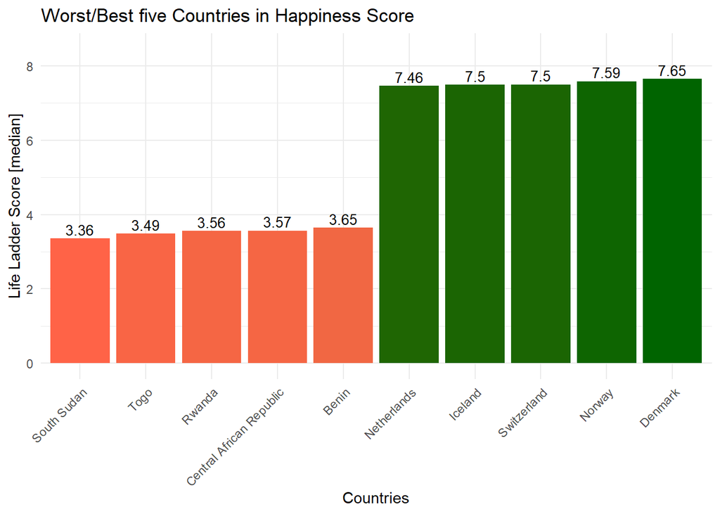

```r
ggplot(best_worst_med, aes(x = reorder(Country_name, Life_Ladder),
                       y = Life_Ladder,
                       fill = Life_Ladder)) +
  geom_bar(stat = "identity") +
  scale_fill_gradient(low = "tomato", high = "darkgreen", guide = "none") +
  geom_text(aes(label = round(Life_Ladder, 2)),
            vjust = -0.3, size = 3.5) +
  labs(x = "Countries",
       y = "Life Ladder Score [median]",
       title = "Worst/Best five Countries in Happiness Score") +
  theme_minimal() +
  theme(axis.text.x = element_text(angle = 45, hjust = 1)) +
  coord_cartesian(ylim = c(0,max(best_worst$Life_Ladder)*1.1))
```

Diese Abbildung bestätigt die Ergebnisse aus der Abbildung die auf den Werten basierend auf dem arithmetischen Mittel basierten. Die fünf Länder mit dem schlechtesten Wert (im Median) sind bis auf Burundi, stattdessen gehört Benin dazu identisch. Bei den fünf Ländern mit dem besten Wert (im Median) gehört nun Island statt Finnland zu den fünf Ländern mit dem höchsten Wert. Dänemark ist auch wenn man den Median als Metrik verwendet den höchsten Wert und auch die Reihenfolge der übrigen Länder weist eine Ähnlichkeit zu der vorherigen Abbildung auf.

Außerdem werden die einzelnen Jahre für die Daten existieren in einem zeitlichen Verlauf dargestellt um die Streuung der Daten zu beurteilen, dafür werden die 10 Länder aus der Grafik mit dem arithmetischen Mittel verwendet.

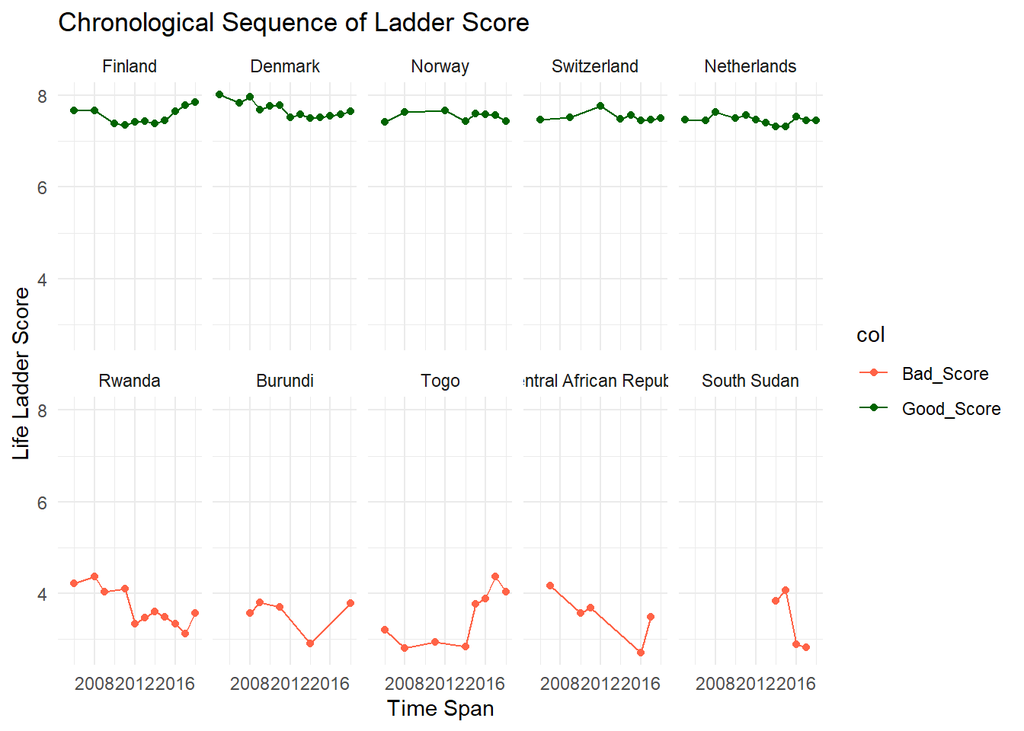

```r
ggplot(data = time, aes(x = Year, y = Life_Ladder, group = Country_name, color = col))+geom_line()+ geom_point()+theme_minimal()+
  labs(x = "Time Span", y = "Life Ladder Score", title = "Chronological Sequence of Ladder Score")+
  # scale_x_continuous(breaks = sort(unique(time$Year)))+
  scale_color_manual(values = c("Good_Score" = "darkgreen", "Bad_Score" = "tomato"))+
  facet_wrap(~Country_name, scales = "fixed", ncol = 5)
```

In dieser Abbildung fällt auf das die fünf Länder die im Durchschnitt den schlechtesten Wert für Zufriedenheit haben eine größere Streuung besitzen als die Länder die einen guten Wert für Zufriedenheit haben. Dies gilt zum einen über die jeweiligen Zeitspannen für die Daten existieren, als auch innerhalb der Gruppen der Länder mit dem höchsten/niedrigsten durchschnittlichen Wert.

```r
# Abweichungen innerhalb der guten Länder
good_sd <- sd(df[df$Country_name %in% c("Netherlands", "Switzerland", "Norway", "Finland", "Denmark"),]$Life_Ladder)

# Abweichung innerhalb der schlechten Länder
bad_sd <- sd(df[df$Country_name %in% c("South Sudan", "Togo", "Central African Republic", "Burundi", "Rwanda"),]$Life_Ladder)

paste("Die Standardabweichung innerhalb der Länder mit dem schlechtesten Score beträgt:",round(bad_sd,3), "Die Standardabweichung innerhalb der Länder mit dem besten Score beträgt:", round(good_sd,3))
```

```
## [1] "Die Standardabweichung innerhalb der Länder mit dem schlechtesten Score beträgt: 0.485 Die Standardabweichung innerhalb der Länder mit dem besten Score beträgt: 0.156"
```

Es soll der Zusammenhang zwischen der “Hauptvariable” Life Ladder und den restlichen erhobenen Variablen ermittelt werden. Um den Zusammenhang zwischen Variablen zu messen benötigt man ein geeignetes Zusammenhangsmaß.Ein solches Maß ist beispielsweise der Bravais Pearson Korrelationskoeffizient, welcher Werte innerhalb von [-1,1] annehmen kann, wobei ein Wert von -1 eine starke negative Korrelation ausdrückt, ein Wert von 1 eine starke positive Korrelation beschreibt und ein Wert von 0 unkorreliertheit zwischen zwei Variablen bedeutet.

[figure not shown]

```r
# Barplot
ggplot(cor_df, aes(x = reorder(Variable, Correlation), y = Correlation, fill = Correlation)) +
  geom_bar(stat = "identity", na.rm = TRUE) +
  coord_flip() +
  scale_fill_gradient2(low = "blue", mid = "white", high = "red", midpoint = 0) +
  labs(title = "Variable Correlation with Life Ladder Score",
       x = "Variable", y = "Correlation") +
  theme_minimal() +
  theme(axis.text = element_text(size = 10),
        plot.title = element_text(hjust = 0.5))
```

In dieser Abbildung sind die Korrelationen jeder Variable mit Life Ladder dargestellt. Die Korrelation von Life Ladder zu sich selber beträgt 1 und bezeichnet eine “perfekte” Korrelation und ist zu Anschauungszwecken ebenfalls im Plot enthalten. In der Statistik gibt es den Begriff der Multikollinearität. Wenn zwei Variablen durch einen gemeinsamen Effekt beeinflusst werden, dann werden sie obwohl sie eine unterschiedliche Bedeutung haben eine hohe Korrelation aufweisen. Da man dann unter Umständen diesen Effekt in mehreren Variablen merkt, ist es sinnvoll die Kovarianzstruktur genauer zu betrachten, um nur die Variablen zu beachten die einen hohen Beitrag zur Gesamtvarianz haben.

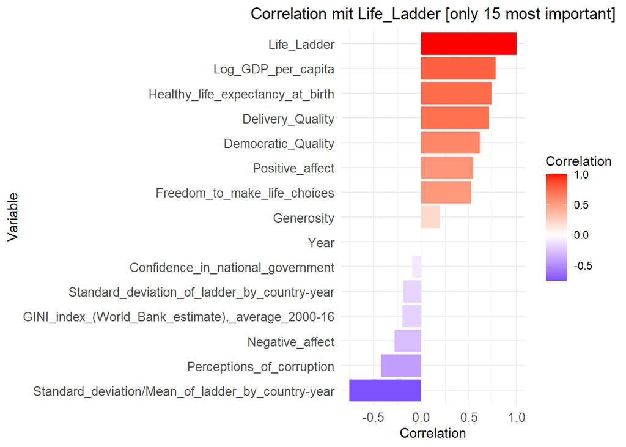

```r
ggplot(cor_df[cor_df$Variable %in% top15,], aes(x = reorder(Variable, Correlation), y = Correlation, fill = Correlation)) +
  geom_bar(stat = "identity", na.rm = TRUE) +
  coord_flip() +
  scale_fill_gradient2(low = "blue", mid = "white", high = "red", midpoint = 0) +
  labs(title = "Correlation mit Life_Ladder [only 15 most important]",
       x = "Variable", y = "Correlation") +
  theme_minimal() +
  theme(axis.text = element_text(size = 10),
        plot.title = element_text(hjust = 0.5))
```

```r
sum(var_df[var_df$Spalte %in% top15,]$Varianz_erklärt)
```

```
## [1] 0.9375
```

Die 15 in der Grafik dargestellten Variablen weisen den höchsten Beitrag zur Varianz auf. Insgesamt erklären machen diese 15 Spalten 93.75% der gesamten Varianz aus. Die stärkste positive Korrelation liegt bei dem logarithmierten Pro-Kopf Bruttoninlandsprodukt und Life Ladder vor.

```r
#Gini Koeffizient

# last_year <- df %>% group_by("Country_Name") %>%


means
```

```
## # A tibble: 165 × 25
##    Country_name Life_Ladder Log_GDP_per_capita Social_support
##    <chr>              <dbl>              <dbl>          <dbl>
##  1 Afghanistan         3.71               7.44          0.516
##  2 Albania             4.99               9.26          0.720
##  3 Algeria             5.48               9.51          0.804
##  4 Angola              4.42               8.71          0.738
##  5 Argentina           6.36               9.83          0.906
##  6 Armenia             4.44               8.93          0.714
##  7 Australia           7.30              10.7           0.949
##  8 Austria             7.25              10.7           0.927
##  9 Azerbaijan          4.92               9.63          0.762
## 10 Bahrain             5.86              10.6           0.884
## # ℹ 155 more rows
## # ℹ 21 more variables: Healthy_life_expectancy_at_birth <dbl>,
## #   Freedom_to_make_life_choices <dbl>, Generosity <dbl>,
## #   Perceptions_of_corruption <dbl>, Positive_affect <dbl>,
## #   Negative_affect <dbl>, Confidence_in_national_government <dbl>,
## #   Democratic_Quality <dbl>, Delivery_Quality <dbl>,
## #   `Standard_deviation_of_ladder_by_country-year` <dbl>, …
```

```r
means %>% summarise(Gini_Score_LGDP = Gini(exp(Log_GDP_per_capita), na.rm = TRUE))
```

```
## # A tibble: 1 × 1
##   Gini_Score_LGDP
##             <dbl>
## 1           0.535
```

```r
means %>% summarise(Gini_Score_Ladder = Gini(Life_Ladder, na.rm = TRUE))
```

```
## # A tibble: 1 × 1
##   Gini_Score_Ladder
##               <dbl>
## 1             0.113
```

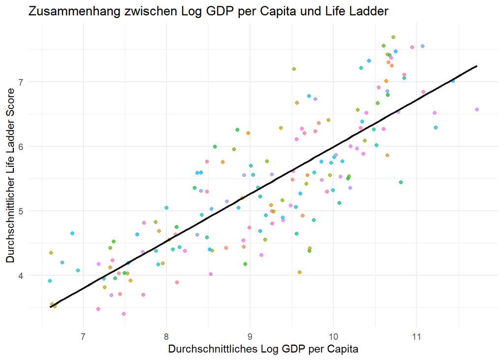

```r
# Unterschied zwischen der Verteilung von Life Ladder und von Log GDP per Capita


ggplot(means, aes(x = (Log_GDP_per_capita), y = Life_Ladder)) +
  geom_point(aes(color = Country_name), alpha = 0.7) +
  geom_smooth(method = "lm", se = FALSE, color = "black") +
  theme_minimal() +
  labs(
    title = "Zusammenhang zwischen Log GDP per Capita und Life Ladder",
    x = "Durchschnittliches Log GDP per Capita",
    y = "Durchschnittlicher Life Ladder Score",
    color = "Land"
  ) + theme(legend.position = "none")
```

```r
df_sorted_GDP <- means[order(means$Log_GDP_per_capita), ]

df_sorted_GDP$cum_share <- cumsum(exp(df_sorted_GDP$Log_GDP_per_capita)) / sum(exp(df_sorted_GDP$Log_GDP_per_capita), na.rm = TRUE)


length(na.omit(df_sorted_GDP[df_sorted_GDP$cum_share > 0.5,]$Country_name))
```

```
## [1] 28
```

```r
df_sorted_LL <- means[order(means$Life_Ladder), ]

df_sorted_LL$cum_share <- cumsum(df_sorted_LL$Life_Ladder) / sum(df_sorted_GDP$Life_Ladder, na.rm = TRUE)

length(na.omit(df_sorted_LL[df_sorted_LL$cum_share > 0.5,]$Country_name))
```

```
## [1] 70
```

```r
# Lebenszufriedenheit ist nicht so ungleich verteilt wie das Pro Kopf Einkommen
```

```r
summary(lm(data = means,formula = Life_Ladder ~ Log_GDP_per_capita + Social_support + Democratic_Quality))
```

```
##
## Call:
## lm(formula = Life_Ladder ~ Log_GDP_per_capita + Social_support +
##     Democratic_Quality, data = means)
##
## Residuals:
##      Min       1Q   Median       3Q      Max
## -1.79632 -0.32951 -0.00002  0.36076  1.29163
##
## Coefficients:
##                    Estimate Std. Error t value Pr(>|t|)
## (Intercept)        -0.79003    0.44021  -1.795  0.07463 .
## Log_GDP_per_capita  0.41814    0.05478   7.633 2.08e-12 ***
## Social_support      2.94859    0.54230   5.437 2.03e-07 ***
## Democratic_Quality  0.22597    0.06325   3.572  0.00047 ***
## ---
## Signif. codes:  0 '***' 0.001 '**' 0.01 '*' 0.05 '.' 0.1 ' ' 1
##
## Residual standard error: 0.5297 on 157 degrees of freedom
##   (4 Beobachtungen als fehlend gelöscht)
## Multiple R-squared:  0.7612, Adjusted R-squared:  0.7566
## F-statistic: 166.8 on 3 and 157 DF,  p-value: < 2.2e-16
```

```r
summary(lm(data = means, formula = Life_Ladder ~ Healthy_life_expectancy_at_birth))
```

```
##
## Call:
## lm(formula = Life_Ladder ~ Healthy_life_expectancy_at_birth,
##     data = means)
##
## Residuals:
##      Min       1Q   Median       3Q      Max
## -1.50561 -0.49057 -0.00576  0.52262  1.36856
##
## Coefficients:
##                                   Estimate Std. Error t value Pr(>|t|)
## (Intercept)                      -1.586377   0.427370  -3.712 0.000284 ***
## Healthy_life_expectancy_at_birth  0.111652   0.006791  16.441  < 2e-16 ***
## ---
## Signif. codes:  0 '***' 0.001 '**' 0.01 '*' 0.05 '.' 0.1 ' ' 1
##
## Residual standard error: 0.6573 on 160 degrees of freedom
##   (3 Beobachtungen als fehlend gelöscht)
## Multiple R-squared:  0.6282, Adjusted R-squared:  0.6258
## F-statistic: 270.3 on 1 and 160 DF,  p-value: < 2.2e-16
```